# Effect of an organic food intervention on biomarkers of exposure to lead and cadmium in primary school children: A cluster-randomized cross-over trial - Part 1

Nikolaos Efthymiou

18/08/2022

This script includes Part 1 of the analysis (descriptives) and the dataset that will be the input of Part 2 of the analysis.

### Table 1 A - Demographic characteristics - Study participants

Demographic & other characteristics of participants with >=12 days in the organic phase by group

|  | Overall | First organic | First conventional | p | test |
| --- | --- | --- | --- | --- | --- |
| n | 149 | 43 | 106 |  |  |
| Group1 = First conventional (%) | 106 (71.1) | 0 ( 0.0) | 106 (100.0) | <0.001 |  |
| medulev1 (%) |  |  |  | 0.871 |  |
| Secondary | 26 (17.7) | 7 (16.7) | 19 ( 18.1) |  |  |
| University/college | 80 (54.4) | 22 (52.4) | 58 ( 55.2) |  |  |
| Master/PhD | 41 (27.9) | 13 (31.0) | 28 ( 26.7) |  |  |
| fedulev1 (%) |  |  |  | 0.447 |  |
| Primary | 2 ( 1.4) | 0 ( 0.0) | 2 ( 2.0) |  |  |
| Secondary | 43 (30.3) | 10 (24.4) | 33 ( 32.7) |  |  |
| University/college | 56 (39.4) | 16 (39.0) | 40 ( 39.6) |  |  |
| Master/PhD | 41 (28.9) | 15 (36.6) | 26 ( 25.7) |  |  |
| Sex = Female (%) | 73 (49.0) | 14 (32.6) | 59 ( 55.7) | 0.018 |  |
| age_baseline (mean (SD)) | 11.16 (0.59) | 11.03 (0.53) | 11.21 (0.61) | 0.101 |  |
| Waist_start (median [IQR]) | 69.00 [63.00, 77.00] | 69.00 [66.50, 81.50] | 69.00 [62.00, 76.00] | 0.153 | nonnorm |
| Waist_endorg (median [IQR]) | 68.00 [63.00, 74.00] | 69.00 [65.00, 74.00] | 68.00 [62.50, 73.50] | 0.427 | nonnorm |
| Waist_endconv (median [IQR]) | 69.00 [66.50, 75.00] | 69.00 [66.50, 75.00] | NA [NA, NA] | NA | nonnorm |
| BMI_start (mean (SD)) | 19.24 (3.48) | 20.06 (4.08) | 18.91 (3.16) | 0.067 |  |
| BMI_endorg (mean (SD)) | 18.65 (2.97) | 19.37 (3.29) | 18.37 (2.80) | 0.084 |  |
| BMI_endcon (mean (SD)) | 19.51 (3.35) | 19.51 (3.35) | NaN (NA) | NA |  |
| BMI_for_age_start (%) |  |  |  | 0.114 |  |
| Thinness | 2 ( 1.4) | 0 ( 0.0) | 2 ( 1.9) |  |  |
| Normal | 90 (60.8) | 23 (54.8) | 67 ( 63.2) |  |  |
| Overweight | 36 (24.3) | 9 (21.4) | 27 ( 25.5) |  |  |
| Obese | 20 (13.5) | 10 (23.8) | 10 ( 9.4) |  |  |
| BMI_for_age_endorg (%) |  |  |  | 0.140 |  |
| Thinness | 2 ( 1.5) | 0 ( 0.0) | 2 ( 2.1) |  |  |
| Normal | 88 (66.7) | 22 (59.5) | 66 ( 69.5) |  |  |
| Overweight | 29 (22.0) | 8 (21.6) | 21 ( 22.1) |  |  |
| Obese | 13 ( 9.8) | 7 (18.9) | 6 ( 6.3) |  |  |
| BMI_for_age_endcon (%) |  |  |  | NaN |  |
| Normal | 19 (54.3) | 19 (54.3) | 0 ( NaN) |  |  |
| Overweight | 9 (25.7) | 9 (25.7) | 0 ( NaN) |  |  |
| Obese | 7 (20.0) | 7 (20.0) | 0 ( NaN) |  |  |
| daysorgcat (%) |  |  |  | 0.589 |  |
| 12-21 days | 12 ( 8.1) | 4 ( 9.3) | 8 ( 7.5) |  |  |
| 22-28 days | 4 ( 2.7) | 2 ( 4.7) | 2 ( 1.9) |  |  |
| 29-40 days | 133 (89.3) | 37 (86.0) | 96 ( 90.6) |  |  |
| Handinmouth1 = Yes (%) | 36 (24.3) | 10 (23.8) | 26 ( 24.5) | 1.000 |  |

### Table 1 B - Children’s activities

Time spent by children outside & in physical and sedentary activities (hours per week) for 149 participants by group

|  | First organic | First conventional | p | test |
| --- | --- | --- | --- | --- |
| n | 43 | 106 |  |  |
| garden_week (mean (SD)) | 2.30 (4.01) | 2.69 (3.93) | 0.592 |  |
| park_week (mean (SD)) | 0.80 (1.25) | 0.54 (1.30) | 0.266 |  |
| run_week (mean (SD)) | 0.26 (0.69) | 0.99 (3.10) | 0.127 |  |
| cyc_week (mean (SD)) | 0.55 (1.07) | 0.56 (1.15) | 0.960 |  |
| bask_week (mean (SD)) | 0.33 (0.80) | 0.24 (0.85) | 0.555 |  |
| foot_week (mean (SD)) | 1.21 (2.35) | 1.19 (2.47) | 0.954 |  |
| voll_week (mean (SD)) | 0.09 (0.43) | 0.15 (0.73) | 0.626 |  |
| swim_week (mean (SD)) | 0.78 (2.19) | 0.41 (1.54) | 0.240 |  |
| danc_week (mean (SD)) | 0.69 (1.46) | 0.84 (1.91) | 0.626 |  |
| tv_week (mean (SD)) | 8.59 (7.32) | 10.33 (6.33) | 0.149 |  |
| comp_week (mean (SD)) | 3.03 (2.59) | 2.18 (3.08) | 0.113 |  |
| tablet_week (mean (SD)) | 3.80 (4.28) | 3.92 (5.57) | 0.892 |  |
| mobile_week (mean (SD)) | 1.87 (3.18) | 3.57 (5.97) | 0.079 |  |
| outside_time (mean (SD)) | 3.10 (4.23) | 3.23 (4.10) | 0.868 |  |
| physactiv_time (median [IQR]) | 3.50 [1.75, 5.50] | 4.00 [2.00, 6.00] | 0.291 | nonnorm |
| sedentactiv_time (median [IQR]) | 20.50 [14.50, 26.50] | 16.40 [12.00, 28.00] | 0.258 | nonnorm |

### Table 1 C - Children’s food frequency

Frequency of food categories consumed by children during the conventional phase by group (portions per week)

|  | Overall | First organic | First conventional | p | test |
| --- | --- | --- | --- | --- | --- |
| n | 135 | 37 | 98 |  |  |
| milkproducts (mean (SD)) | 15.85 (8.82) | 15.85 (8.64) | 15.85 (8.93) | 0.999 |  |
| meatfisheggsnutslegumes (mean (SD)) | 15.05 (7.31) | 10.72 (4.46) | 16.69 (7.52) | <0.001 |  |
| vegetables (mean (SD)) | 5.38 (3.84) | 3.78 (3.06) | 5.98 (3.95) | 0.003 |  |
| fruits (mean (SD)) | 9.70 (6.69) | 8.32 (5.33) | 10.22 (7.09) | 0.143 |  |
| cereals (mean (SD)) | 21.78 (9.52) | 19.45 (11.57) | 22.66 (8.52) | 0.081 |  |
| fats (mean (SD)) | 32.47 (17.70) | 25.43 (11.27) | 35.13 (18.96) | 0.004 |  |

## Urinary data

Percentage of samples below the LOD and LOQ (Units Creatinine:g/l, Cd:μg/L, Pb:μg/L)

Below LOD: Cd (<0.01) , Pb (<0.045)  
Below LOQ: Cd (<0.029), Pb (<0.135)

|  | Cd(%) | Pb(%) |
| --- | --- | --- |
| <LOD | 0.84 | 0.0 |
| >LOD and <LOQ | 4.89 | 0.6 |

### Table 2 A - Percentiles of metals and oxidative stress biomarkers overall

- Note: the tables are based on the imputed data
- Units: Cd:ng/L, Pb:ng/L, Ohdg:ug/L MDA:nmol/L 8-iso-pgf2a:ng/L

Quantiles of the raw concentrations

| Biomarkers | 0% | 5% | 25% | 50% | 75% | 95% | 100% |
| --- | --- | --- | --- | --- | --- | --- | --- |
| Cd1000 | 5.00 | 14.50 | 109.20 | 154.43 | 187.02 | 406.82 | 1178.40 |
| Isopgf2a1000 | 252.88 | 1392.36 | 2519.54 | 3350.98 | 4351.02 | 6485.22 | 13211.60 |
| Mda1000 | 140.00 | 390.00 | 692.50 | 960.00 | 1300.00 | 1970.00 | 2980.00 |
| Ohdg | 55.68 | 146.85 | 241.37 | 326.83 | 486.93 | 789.05 | 1369.63 |
| Pb1000 | 67.50 | 196.95 | 339.53 | 591.52 | 1032.58 | 1719.09 | 7643.98 |

- Units: Cd:ng/g Cr, Pb:ng/g Cr, Ohdg:ug/g Cr MDA:nmol/g Cr 8-iso-pgf2a:ng/g Cr

Quantiles of the creatinine adjusted concentrations

| Biomarkers | 0% | 5% | 25% | 50% | 75% | 95% | 100% |
| --- | --- | --- | --- | --- | --- | --- | --- |
| adj_Cd1000 | 4.55 | 19.26 | 81.78 | 125.10 | 203.91 | 523.92 | 2369.63 |
| adj_Isopgf2a1000 | 260.70 | 1339.27 | 2231.55 | 2985.75 | 3930.90 | 6318.50 | 22507.62 |
| adj_Mda1000 | 189.19 | 530.66 | 708.33 | 852.74 | 1027.40 | 1411.96 | 3846.15 |
| adj_Ohdg | 69.39 | 116.42 | 211.74 | 307.77 | 454.86 | 798.17 | 1983.75 |
| adj_Pb1000 | 54.44 | 143.73 | 296.14 | 544.19 | 931.34 | 2087.56 | 15378.60 |

### Table 2 A - Percentiles of metals and oxidative stress biomarkers during the organic treatment

- Note: the tables are based on the imputed data
- Units: Cd:ng/L, Pb:ng/L, Ohdg:ug/L MDA:nmol/L 8-iso-pgf2a:ng/L

Quantiles of the raw concentrations during the organic treatment

| Biomarkers | 0% | 5% | 25% | 50% | 75% | 95% | 100% |
| --- | --- | --- | --- | --- | --- | --- | --- |
| Cd1000 | 5.00 | 14.50 | 112.16 | 149.61 | 180.40 | 345.65 | 1164.89 |
| Isopgf2a1000 | 335.41 | 1544.58 | 2661.76 | 3621.61 | 4612.12 | 6669.59 | 10376.71 |
| Mda1000 | 140.00 | 414.50 | 740.00 | 1030.00 | 1357.50 | 2010.00 | 2980.00 |
| Ohdg | 58.29 | 144.81 | 236.81 | 325.22 | 486.66 | 787.51 | 1369.63 |
| Pb1000 | 67.50 | 207.51 | 325.72 | 540.13 | 997.28 | 1725.33 | 7643.98 |

- Units: Cd:ng/g Cr, Pb:ng/g Cr, Ohdg:ug/g Cr MDA:nmol/g Cr 8-iso-pgf2a:ng/g Cr

Quantiles of the creatinine adjusted concentrations during the organic treatment

| Biomarkers | 0% | 5% | 25% | 50% | 75% | 95% | 100% |
| --- | --- | --- | --- | --- | --- | --- | --- |
| adj_Cd1000 | 6.97 | 19.33 | 80.12 | 121.86 | 183.70 | 473.55 | 2369.63 |
| adj_Isopgf2a1000 | 447.21 | 1337.99 | 2295.83 | 3044.49 | 3955.55 | 6164.66 | 22507.62 |
| adj_Mda1000 | 237.29 | 552.99 | 729.45 | 846.98 | 1029.85 | 1486.31 | 3846.15 |
| adj_Ohdg | 69.39 | 107.52 | 201.62 | 295.40 | 446.59 | 798.50 | 1575.87 |
| adj_Pb1000 | 54.44 | 139.97 | 274.39 | 509.01 | 903.36 | 2047.24 | 8666.27 |

### Table 2 B - Percentiles of the metals and oxidative stress biomarkers during the conventional treatment

- Note: the tables are based on the imputed data
- Units: Cd:ng/L, Pb:ng/L, Ohdg:ug/L MDA:nmol/L 8-iso-pgf2a:ng/L

Quantiles of the raw concentrations during the conventional treatment

| Biomarkers | 0% | 5% | 25% | 50% | 75% | 95% | 100% |
| --- | --- | --- | --- | --- | --- | --- | --- |
| Cd1000 | 5.00 | 14.50 | 104.14 | 155.62 | 204.96 | 649.93 | 1178.40 |
| Isopgf2a1000 | 252.88 | 1350.94 | 2476.88 | 3147.20 | 4086.96 | 6194.43 | 13211.60 |
| Mda1000 | 140.00 | 370.00 | 670.00 | 930.00 | 1192.50 | 1763.00 | 2840.00 |
| Ohdg | 55.68 | 152.21 | 247.28 | 332.51 | 486.91 | 779.95 | 1330.10 |
| Pb1000 | 67.50 | 192.84 | 365.79 | 626.47 | 1045.08 | 1703.25 | 4387.71 |

- Units: Cd:ng/g Cr, Pb:ng/g Cr, Ohdg:ug/g Cr MDA:nmol/g Cr 8-iso-pgf2a:ng/g Cr

Quantiles of the creatinine adjusted concentrations during the conventional treatment

| Biomarkers | 0% | 5% | 25% | 50% | 75% | 95% | 100% |
| --- | --- | --- | --- | --- | --- | --- | --- |
| adj_Cd1000 | 4.55 | 19.39 | 84.47 | 133.29 | 224.00 | 542.45 | 1576.34 |
| adj_Isopgf2a1000 | 260.70 | 1341.83 | 2114.95 | 2975.45 | 3883.19 | 6322.08 | 21641.70 |
| adj_Mda1000 | 189.19 | 508.80 | 690.74 | 859.85 | 1017.99 | 1357.73 | 2461.54 |
| adj_Ohdg | 83.69 | 126.22 | 221.84 | 318.23 | 464.25 | 774.84 | 1983.75 |
| adj_Pb1000 | 92.89 | 158.71 | 311.77 | 584.07 | 971.65 | 2144.38 | 15378.60 |

### Table 3 A - Geometric means of metals

- Note: the tables are based on the imputed data
- Units: Cd:ng/L, Pb:ng/L

Geometric means of raw lead (overall, organic period (o), conventional period(c)

| pb_gm | 583.6352 |
| --- | --- |
| pb_gm_o | 564.2042 |
| pb_gm_c | 602.8762 |

Geometric means of raw cadmium (overall, organic period (o), conventional period(c)

| cd_gm | 133.1405 |
| --- | --- |
| cd_gm_o | 130.8447 |
| cd_gm_c | 135.3775 |

- Units: Cd:ng/g Cr, Pb:ng/g Cr

Geometric means of creatinine-adjusted lead (overall, organic period (o), conventional period(c)

| crpb_gm | 539.6443 |
| --- | --- |
| crpb_gm_o | 504.2787 |
| crpb_gm_c | 575.8462 |

Geometric means of creatinine-adjusted cadmium (overall, organic period (o), conventional period(c)

| crcd_gm | 123.1052 |
| --- | --- |
| crcd_gm_o | 116.9473 |
| crcd_gm_c | 129.3079 |

### Table 3 B - Geometric standard deviations of metals

- Note: the tables are based on the imputed data
- Units: Cd:ng/L, Pb:ng/L

Geometric standard deviations of raw lead (overall, organic period (o), conventional period(c)

| pb_gsd | 2.000375 |
| --- | --- |
| pb_gsd_o | 2.023580 |
| pb_gsd_c | 1.976543 |

Geometric standard deviations of raw cadmium (overall, organic period (o), conventional period(c)

| cd_gsd | 2.294306 |
| --- | --- |
| cd_gsd_o | 2.207015 |
| cd_gsd_c | 2.378716 |

- Units: Cd:ng/g Cr, Pb:ng/g Cr

Geometric standard deviations of creatinine-adjusted lead (overall, organic period (o), conventional period(c)

| crpb_gsd | 2.298703 |
| --- | --- |
| crpb_gsd_o | 2.316263 |
| crpb_gsd_c | 2.272152 |

Geometric standard deviations of creatinine-adjusted cadmium (overall, organic period (o), conventional period(c)

| crcd_gsd | 2.494250 |
| --- | --- |
| crcd_gsd_o | 2.408452 |
| crcd_gsd_c | 2.572093 |

## Percent change - Baseline and after 40 days of organic diet

### Tables 4 - Percent change for last conventional sample to last organic sample for Pb, Cd

- Outcome: %(last of conventional-end of organic)/last of conventional
- Note: the tables are based on the imputed data
- Units: Cd:ng/L, Pb:ng/L

|  | estimate | lowerCI | upperCI | pvalue |
| --- | --- | --- | --- | --- |
| logPb | 1.2 | -1.2 | 3.7 | 0.316 |
| logCd | -2.0 | -8.6 | 4.5 | 0.535 |

- Units: Cd:ng/g Cr, Pb:ng/g Cr

|  | estimate | lowerCI | upperCI | pvalue |
| --- | --- | --- | --- | --- |
| log-cradjPb | 3.9 | 1.2 | 6.6 | 0.005 |
| log-cradjCd | 1.3 | -5.6 | 8.2 | 0.701 |

### Table 5 - Summary tables of metal metabolites and oxidative stress biomarkers overall and by treatment

- Note: the tables are based on the imputed data
- Units: Cd:ng/L, Pb:ng/L, Ohdg:ug/L MDA:nmol/L 8-iso-pgf2a:ng/L

Summary table of measurements per phase - non-creatinine adjusted

|  | Overall | Conventional | Organic | p | test |
| --- | --- | --- | --- | --- | --- |
| n | 838 | 428 | 410 |  |  |
| Cd1000 (median [IQR]) | 154.43 [109.20, 187.02] | 155.62 [104.14, 204.96] | 149.61 [112.16, 180.40] | 0.556 | nonnorm |
| Pb1000 (median [IQR]) | 591.52 [339.53, 1032.58] | 626.47 [365.79, 1045.08] | 540.13 [325.72, 997.28] | 0.120 | nonnorm |
| Mda1000 (median [IQR]) | 960.00 [692.50, 1300.00] | 930.00 [670.00, 1192.50] | 1030.00 [740.00, 1357.50] | 0.001 | nonnorm |

Summary table of measurements per phase - non-creatinine adjusted

|  | Overall | Conventional | Organic | p | test |
| --- | --- | --- | --- | --- | --- |
| n | 798 | 408 | 390 |  |  |
| Isopgf2a1000 (median [IQR]) | 3350.98 [2519.54, 4351.02] | 3147.20 [2476.88, 4086.96] | 3621.61 [2661.76, 4612.12] | <0.001 | nonnorm |

Summary table of measurements per phase - non-creatinine adjusted

|  | Overall | Conventional | Organic | p | test |
| --- | --- | --- | --- | --- | --- |
| n | 799 | 390 | 409 |  |  |
| Ohdg (median [IQR]) | 326.83 [241.37, 486.93] | 332.51 [247.28, 486.91] | 325.22 [236.81, 486.66] | 0.576 | nonnorm |

- Units: Cd:ng/g Cr, Pb:ng/g Cr, Ohdg:ug/g Cr MDA:nmol/g Cr 8-iso-pgf2a:ng/g Cr

Summary table of measurements per phase - creatinine adjusted

|  | Overall | Conventional | Organic | p | test |
| --- | --- | --- | --- | --- | --- |
| n | 838 | 428 | 410 |  |  |
| adj_Cd1000 (median [IQR]) | 125.10 [81.78, 203.91] | 133.29 [84.47, 224.00] | 121.86 [80.12, 183.70] | 0.057 | nonnorm |
| adj_Pb1000 (median [IQR]) | 544.19 [296.14, 931.34] | 584.07 [311.77, 971.65] | 509.01 [274.39, 903.36] | 0.027 | nonnorm |
| adj_Mda1000 (median [IQR]) | 852.74 [708.33, 1027.40] | 859.85 [690.74, 1017.99] | 846.98 [729.45, 1029.85] | 0.339 | nonnorm |

Summary table of measurements per phase - creatinine adjusted

|  | Overall | Conventional | Organic | p | test |
| --- | --- | --- | --- | --- | --- |
| n | 798 | 408 | 390 |  |  |
| adj_Isopgf2a1000 (median [IQR]) | 2985.75 [2231.55, 3930.90] | 2975.45 [2114.95, 3883.19] | 3044.49 [2295.83, 3955.55] | 0.296 | nonnorm |

Summary table of measurements per phase - creatinine adjusted

|  | Overall | Conventional | Organic | p | test |
| --- | --- | --- | --- | --- | --- |
| n | 799 | 390 | 409 |  |  |
| adj_Ohdg (median [IQR]) | 307.77 [211.74, 454.86] | 318.23 [221.84, 464.25] | 295.40 [201.62, 446.59] | 0.073 | nonnorm |

## Boxplots

The boxplots are included in the script as additional material to what is included in the manuscript. The boxplots are not included in the manuscript. In the boxplots of Cd and Pb the upper 5% of values have been excluded to make the plots easier to read. Imputed data are included.

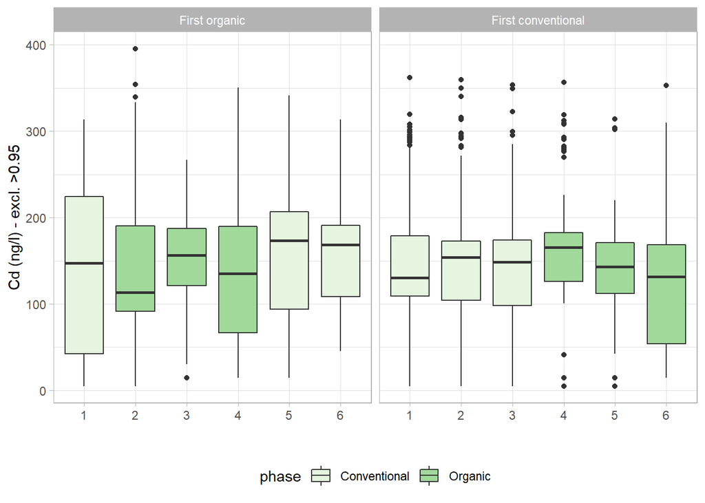

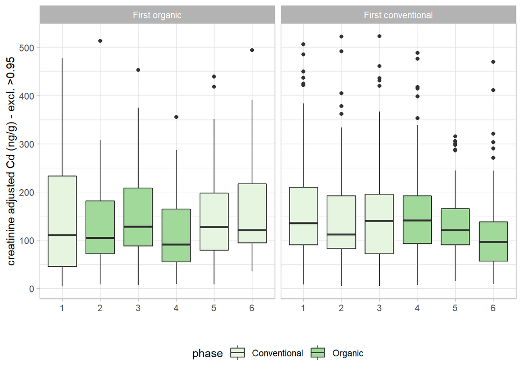

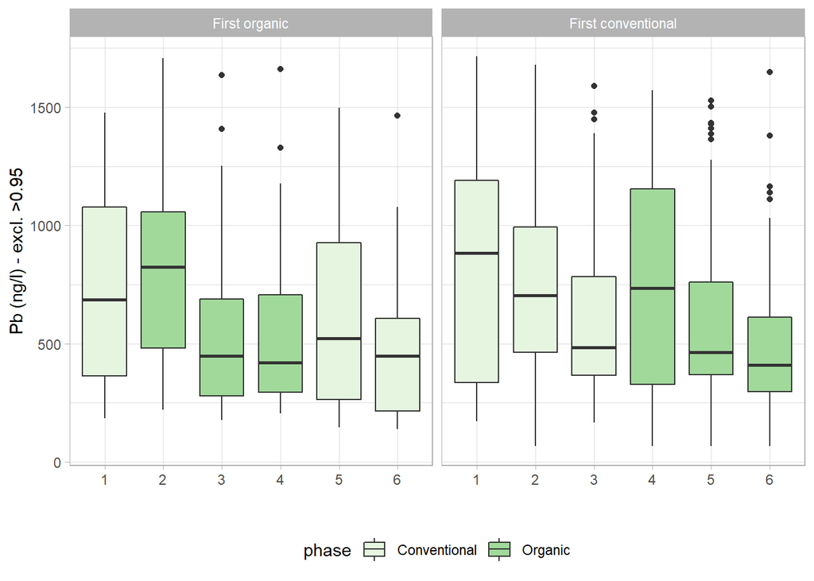

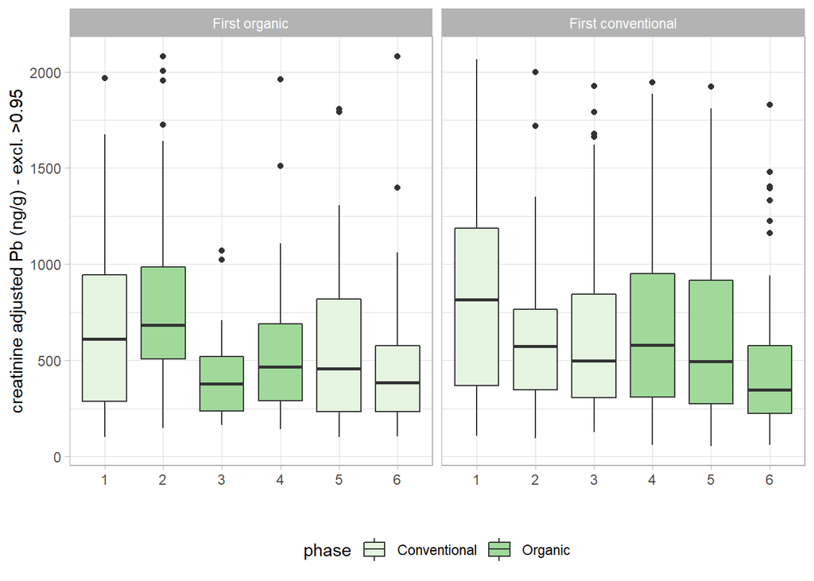

## Spearman correlations

| phase | Cd1000~Pb1000 | adj_Cd1000~adj_Pb1000 |
| --- | --- | --- |
| Conventional | 0.1026994 | 0.2989728 |
| Organic | 0.0892767 | 0.3421277 |
| Overall | 0.0951846 | 0.3180852 |